```python
import pandas as pd
import matplotlib.pyplot as plt
import missingno as msno
import math
import numpy as np
from sklearn.model_selection import train_test_split
from sklearn import preprocessing

from scipy.stats import mstats
```

# Exploring Dataset

1. It looks like that we have some incomple data in the dataset and portion of values in Income,MntCoffee,MntGoldprod, and NumWebVisitsMonth are missing.

```python
df = pd.read_csv('marketing_campaign.csv')
df.info()
df.describe()
```

```
<class 'pandas.core.frame.DataFrame'>
RangeIndex: 2240 entries, 0 to 2239
Data columns (total 20 columns):
 #   Column             Non-Null Count  Dtype
---  ------             --------------  -----
 0   Unnamed: 0         2240 non-null   int64
 1   ID                 2240 non-null   int64
 2   Year_Birth         2240 non-null   int64
 3   Education          2240 non-null   object
 4   Marital_Status     2240 non-null   object
 5   Income             2017 non-null   float64
 6   Kidhome            2240 non-null   int64
 7   Teenhome           2240 non-null   int64
 8   Dt_Customer        2240 non-null   object
 9   Recency            2240 non-null   int64
 10  MntCoffee          2035 non-null   float64
 11  MntFruits          2240 non-null   int64
 12  MntMeatProducts    2240 non-null   int64
 13  MntFishProducts    2240 non-null   int64
 14  MntSweetProducts   2240 non-null   int64
 15  MntGoldProds       2227 non-null   float64
 16  NumWebVisitsMonth  2040 non-null   float64
 17  Complain           2240 non-null   int64
 18  NumPurchases       2240 non-null   int64
 19  UsedCampaignOffer  2240 non-null   int64
dtypes: float64(4), int64(13), object(3)
memory usage: 350.1+ KB
```

|  | Unnamed: 0 | ID | Year_Birth | Income | Kidhome | Teenhome | Recency | MntCoffee | MntFruits | MntMeatProducts | MntFishProducts | MntSweetProducts | MntGoldProds | NumWebVisitsMonth | Complain | NumPurchases | UsedCampaignOffer |
| --- | --- | --- | --- | --- | --- | --- | --- | --- | --- | --- | --- | --- | --- | --- | --- | --- | --- |
| count | 2240.000000 | 2240.000000 | 2240.000000 | 2017.000000 | 2240.000000 | 2240.000000 | 2240.000000 | 2035.000000 | 2240.000000 | 2240.000000 | 2240.000000 | 2240.000000 | 2227.000000 | 2040.000000 | 2240.000000 | 2240.000000 | 2240.000000 |
| mean | 1119.500000 | 5592.159821 | 1968.805804 | 52297.080317 | 0.437946 | 0.506250 | 49.109375 | 304.239312 | 26.302232 | 166.950000 | 37.525446 | 27.062946 | 43.847777 | 5.326961 | 0.009375 | 14.862054 | 0.271875 |
| std | 646.776623 | 3246.662198 | 11.984069 | 25543.108215 | 0.563666 | 0.544538 | 28.962453 | 337.515534 | 39.773434 | 225.715373 | 54.628979 | 41.280498 | 51.897098 | 2.439349 | 0.096391 | 7.677173 | 0.445025 |
| min | 0.000000 | 0.000000 | 1893.000000 | 2447.000000 | -5.000000 | 0.000000 | 0.000000 | 0.000000 | 0.000000 | 0.000000 | 0.000000 | 0.000000 | 0.000000 | 0.000000 | 0.000000 | 0.000000 | 0.000000 |
| 25% | 559.750000 | 2828.250000 | 1959.000000 | 35340.000000 | 0.000000 | 0.000000 | 24.000000 | 23.000000 | 1.000000 | 16.000000 | 3.000000 | 1.000000 | 9.000000 | 3.000000 | 0.000000 | 8.000000 | 0.000000 |
| 50% | 1119.500000 | 5458.500000 | 1970.000000 | 51369.000000 | 0.000000 | 0.000000 | 49.000000 | 177.000000 | 8.000000 | 67.000000 | 12.000000 | 8.000000 | 24.000000 | 6.000000 | 0.000000 | 15.000000 | 0.000000 |
| 75% | 1679.250000 | 8427.750000 | 1977.000000 | 68316.000000 | 1.000000 | 1.000000 | 74.000000 | 505.000000 | 33.000000 | 232.000000 | 50.000000 | 33.000000 | 56.000000 | 7.000000 | 0.000000 | 21.000000 | 1.000000 |
| max | 2239.000000 | 11191.000000 | 1996.000000 | 666666.000000 | 2.000000 | 2.000000 | 99.000000 | 1493.000000 | 199.000000 | 1725.000000 | 259.000000 | 263.000000 | 362.000000 | 20.000000 | 1.000000 | 44.000000 | 1.000000 |

2.

```python
df.count()
```

```
Unnamed: 0           2240
ID                   2240
Year_Birth           2240
Education            2240
Marital_Status       2240
Income               2017
Kidhome              2240
Teenhome             2240
Dt_Customer          2240
Recency              2240
MntCoffee            2035
MntFruits            2240
MntMeatProducts      2240
MntFishProducts      2240
MntSweetProducts     2240
MntGoldProds         2227
NumWebVisitsMonth    2040
Complain             2240
NumPurchases         2240
UsedCampaignOffer    2240
dtype: int64
```

```python
names = list(df.columns.tolist())

missings = [(2240-c,1-(c/2240)) for c in df.count()]
for i,miss in enumerate(missings):
    print(f"colomn name: {names[i]}, amount of missing values: {miss[0]}, ratio of missing: {round(miss[1],3)}")
```

```
colomn name: Unnamed: 0, amount of missing values: 0, ratio of missing: 0.0
colomn name: ID, amount of missing values: 0, ratio of missing: 0.0
colomn name: Year_Birth, amount of missing values: 0, ratio of missing: 0.0
colomn name: Education, amount of missing values: 0, ratio of missing: 0.0
colomn name: Marital_Status, amount of missing values: 0, ratio of missing: 0.0
colomn name: Income, amount of missing values: 223, ratio of missing: 0.1
colomn name: Kidhome, amount of missing values: 0, ratio of missing: 0.0
colomn name: Teenhome, amount of missing values: 0, ratio of missing: 0.0
colomn name: Dt_Customer, amount of missing values: 0, ratio of missing: 0.0
colomn name: Recency, amount of missing values: 0, ratio of missing: 0.0
colomn name: MntCoffee, amount of missing values: 205, ratio of missing: 0.092
colomn name: MntFruits, amount of missing values: 0, ratio of missing: 0.0
colomn name: MntMeatProducts, amount of missing values: 0, ratio of missing: 0.0
colomn name: MntFishProducts, amount of missing values: 0, ratio of missing: 0.0
colomn name: MntSweetProducts, amount of missing values: 0, ratio of missing: 0.0
colomn name: MntGoldProds, amount of missing values: 13, ratio of missing: 0.006
colomn name: NumWebVisitsMonth, amount of missing values: 200, ratio of missing: 0.089
colomn name: Complain, amount of missing values: 0, ratio of missing: 0.0
colomn name: NumPurchases, amount of missing values: 0, ratio of missing: 0.0
colomn name: UsedCampaignOffer, amount of missing values: 0, ratio of missing: 0.0
```

3. Income, MntCoffee, MntMeatProducts, and MntSweetProducts have decent correlation with NumPurchases feature.

```python
df.corr(numeric_only = True)
```

|  | Unnamed: 0 | ID | Year_Birth | Income | Kidhome | Teenhome | Recency | MntCoffee | MntFruits | MntMeatProducts | MntFishProducts | MntSweetProducts | MntGoldProds | NumWebVisitsMonth | Complain | NumPurchases | UsedCampaignOffer |
| --- | --- | --- | --- | --- | --- | --- | --- | --- | --- | --- | --- | --- | --- | --- | --- | --- | --- |
| Unnamed: 0 | 1.000000 | -0.006971 | 0.005586 | 0.016640 | -0.014550 | 0.036062 | 0.000004 | -0.003251 | 0.024295 | 0.000679 | 0.007842 | -0.006920 | 0.014397 | 0.010244 | -0.012182 | 0.007169 | 0.043673 |
| ID | -0.006971 | 1.000000 | 0.000028 | 0.015702 | 0.003254 | -0.002580 | -0.046524 | -0.020890 | 0.004600 | -0.004437 | -0.024475 | -0.007642 | -0.013685 | -0.018879 | 0.033883 | -0.023834 | -0.034489 |
| Year_Birth | 0.005586 | 0.000028 | 1.000000 | -0.161613 | 0.218619 | -0.352111 | -0.019871 | -0.174639 | -0.017917 | -0.030872 | -0.041625 | -0.018133 | -0.053099 | 0.125917 | -0.030128 | -0.168304 | -0.031215 |
| Income | 0.016640 | 0.015702 | -0.161613 | 1.000000 | -0.399894 | 0.020794 | -0.000913 | 0.558439 | 0.421018 | 0.571929 | 0.429283 | 0.430048 | 0.324005 | -0.536321 | -0.026423 | 0.562603 | 0.226246 |
| Kidhome | -0.014550 | 0.003254 | 0.218619 | -0.399894 | 1.000000 | -0.025655 | 0.015477 | -0.478746 | -0.352588 | -0.418982 | -0.365663 | -0.350450 | -0.330563 | 0.424214 | 0.039483 | -0.447073 | -0.165068 |
| Teenhome | 0.036062 | -0.002580 | -0.352111 | 0.020794 | -0.025655 | 1.000000 | 0.016198 | 0.015004 | -0.176764 | -0.261160 | -0.204187 | -0.162475 | -0.018119 | 0.131049 | 0.003138 | 0.133163 | -0.127734 |
| Recency | 0.000004 | -0.046524 | -0.019871 | -0.000913 | 0.015477 | 0.016198 | 1.000000 | 0.024119 | -0.004306 | 0.023056 | 0.001079 | 0.022670 | 0.019496 | -0.022346 | 0.013231 | 0.005740 | -0.100927 |
| MntCoffee | -0.003251 | -0.020890 | -0.174639 | 0.558439 | -0.478746 | 0.015004 | 0.024119 | 1.000000 | 0.377859 | 0.560329 | 0.398729 | 0.384436 | 0.393529 | -0.322496 | -0.041680 | 0.715164 | 0.429107 |
| MntFruits | 0.024295 | 0.004600 | -0.017917 | 0.421018 | -0.352588 | -0.176764 | -0.004306 | 0.377859 | 1.000000 | 0.543105 | 0.594804 | 0.567164 | 0.390926 | -0.411218 | -0.005166 | 0.455461 | 0.146652 |
| MntMeatProducts | 0.000679 | -0.004437 | -0.030872 | 0.571929 | -0.418982 | -0.261160 | 0.023056 | 0.560329 | 0.543105 | 1.000000 | 0.568402 | 0.523846 | 0.345426 | -0.538000 | -0.023483 | 0.554229 | 0.298741 |
| MntFishProducts | 0.007842 | -0.024475 | -0.041625 | 0.429283 | -0.365663 | -0.204187 | 0.001079 | 0.398729 | 0.594804 | 0.568402 | 1.000000 | 0.579870 | 0.422189 | -0.446471 | -0.020953 | 0.469454 | 0.163412 |
| MntSweetProducts | -0.006920 | -0.007642 | -0.018133 | 0.430048 | -0.350450 | -0.162475 | 0.022670 | 0.384436 | 0.567164 | 0.523846 | 0.579870 | 1.000000 | 0.367472 | -0.422313 | -0.022485 | 0.472876 | 0.164510 |
| MntGoldProds | 0.014397 | -0.013685 | -0.053099 | 0.324005 | -0.330563 | -0.018119 | 0.019496 | 0.393529 | 0.390926 | 0.345426 | 0.422189 | 0.367472 | 1.000000 | -0.238404 | -0.030786 | 0.493939 | 0.188321 |
| NumWebVisitsMonth | 0.010244 | -0.018879 | 0.125917 | -0.536321 | 0.424214 | 0.131049 | -0.022346 | -0.322496 | -0.411218 | -0.538000 | -0.446471 | -0.422313 | -0.238404 | 1.000000 | 0.021740 | -0.309666 | -0.076576 |
| Complain | -0.012182 | 0.033883 | -0.030128 | -0.026423 | 0.039483 | 0.003138 | 0.013231 | -0.041680 | -0.005166 | -0.023483 | -0.020953 | -0.022485 | -0.030786 | 0.021740 | 1.000000 | -0.020583 | -0.028209 |
| NumPurchases | 0.007169 | -0.023834 | -0.168304 | 0.562603 | -0.447073 | 0.133163 | 0.005740 | 0.715164 | 0.455461 | 0.554229 | 0.469454 | 0.472876 | 0.493939 | -0.309666 | -0.020583 | 1.000000 | 0.251386 |
| UsedCampaignOffer | 0.043673 | -0.034489 | -0.031215 | 0.226246 | -0.165068 | -0.127734 | -0.100927 | 0.429107 | 0.146652 | 0.298741 | 0.163412 | 0.164510 | 0.188321 | -0.076576 | -0.028209 | 0.251386 | 1.000000 |

4.

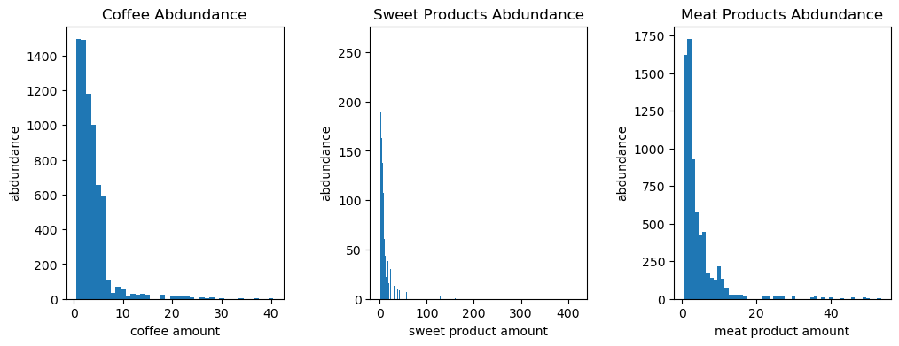

```python
value_counts_1 = df['MntCoffee'].value_counts()
value_counts_2 = df['MntSweetProducts'].value_counts()
value_counts_3 = df['MntMeatProducts'].value_counts()

fig, axs = plt.subplots(1, 3, figsize=(12, 4))

axs[0].bar(value_counts_1.values, value_counts_1.index,width=1)
axs[0].set_title('Coffee Abdundance')
axs[0].set_ylabel('abdundance')
axs[0].set_xlabel('coffee amount')

axs[1].bar(value_counts_2.values, value_counts_2.index,width=1)
axs[1].set_title('Sweet Products Abdundance')
axs[1].set_ylabel('abdundance')
axs[1].set_xlabel('sweet product amount')

axs[2].bar(value_counts_3.values, value_counts_3.index,width=1)
axs[2].set_title('Meat Products Abdundance')
axs[2].set_ylabel('abdundance')
axs[2].set_xlabel('meat product amount')


plt.subplots_adjust(wspace=0.4)

plt.show()
```

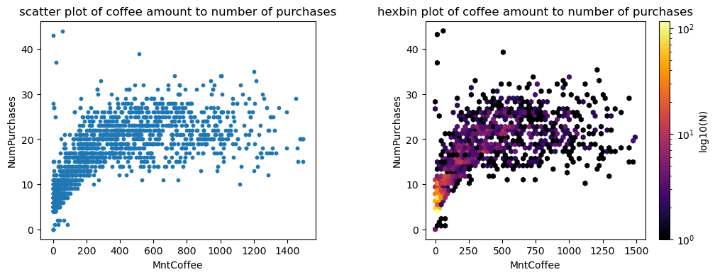

```python
fig, axs = plt.subplots(1, 2, figsize=(12, 4))
axs[0].scatter(df['MntCoffee'].to_list(),df['NumPurchases'].to_list(),s=10)
axs[0].set_title('scatter plot of coffee amount to number of purchases')
axs[0].set_ylabel('NumPurchases')
axs[0].set_xlabel('MntCoffee')

hb =axs[1].hexbin(df['MntCoffee'].to_list(),df['NumPurchases'].to_list(),gridsize=50, bins='log', cmap='inferno')
axs[1].set_title('hexbin plot of coffee amount to number of purchases')
axs[1].set_ylabel('NumPurchases')
axs[1].set_xlabel('MntCoffee')
cb = fig.colorbar(hb, ax=axs[1], label='log10(N)')

plt.subplots_adjust(wspace=0.4)
plt.show()
```

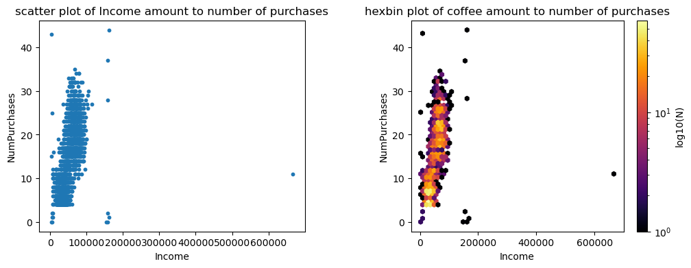

```python
fig, axs = plt.subplots(1, 2, figsize=(12, 4))
axs[0].scatter(df['Income'].to_list(),df['NumPurchases'].to_list(),s=10)
axs[0].set_title('scatter plot of Income amount to number of purchases')
axs[0].set_ylabel('NumPurchases')
axs[0].set_xlabel('Income')

hb =axs[1].hexbin(df['Income'].to_list(),df['NumPurchases'].to_list(),gridsize=50, bins='log', cmap='inferno')
axs[1].set_title('hexbin plot of coffee amount to number of purchases')
axs[1].set_ylabel('NumPurchases')
axs[1].set_xlabel('Income')
cb = fig.colorbar(hb, ax=axs[1], label='log10(N)')

plt.subplots_adjust(wspace=0.4)
plt.show()
```

6.

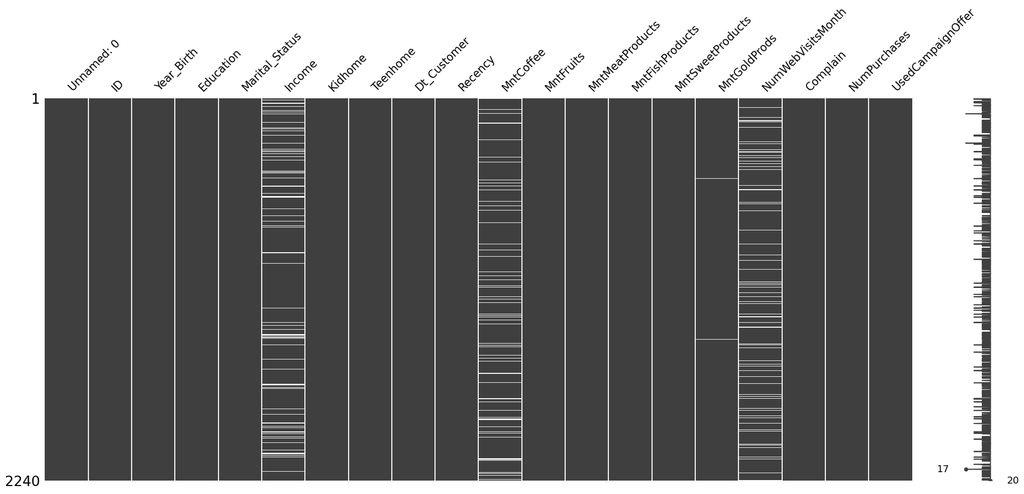

```python
msno.matrix(df)
```

# Preprocessing

7. For categorical data we can replace values with the category that has the most frequency. It is easy to implement but suffers from low perforamance if we have same amount of data in each category. We can use correlation and predict missing value using regression or classification. This method is more accurate but harder to implement.

8.Income, NumWebVisits, and MntCoffee have the most missing values.

```python
df['Income'].fillna(52297.0,inplace=True)
df['MntCoffee'].fillna(177,inplace=True)
df['NumWebVisitsMonth'].fillna(5,inplace=True)
df.dropna(subset=['MntGoldProds'],inplace=True)
temp = df['MntCoffee']
temp = np.array(temp)
df['MntCoffee'] = mstats.winsorize(temp, limits=[0.1, 0.1])
df['Income'] = preprocessing.scale(df['Income'])
df['MntCoffee'] = preprocessing.scale(df['MntCoffee'])
df['NumPurchases'] = preprocessing.scale(df['NumPurchases'])
df['Recency'] = preprocessing.scale(df['Recency'])
df['MntMeatProducts'] = preprocessing.scale(df['MntMeatProducts'])
df['Complain'] = preprocessing.scale(df['Complain'])

marital_cats = {'Single','Married','Divorced','Together'}
ms = df['Marital_Status']
df['Marital_Status'].fillna('Single',inplace=True)
ms = np.where(ms.isin(marital_cats),ms,'Single')
df['Marital_Status'] = ms
one_hot_encoded = pd.get_dummies(df['Marital_Status'])
df = pd.concat([df, one_hot_encoded], axis=1)
```

9.Normalization change scale of data between 0 and 1. It gives all features same importance and decreases the affect of outliers. It is mostly useful when we have features with different scales. It also helps convergence of ML algorithm. Standardization transforms data to have 0 mean and 1 standard derivation. This type of preprocessing is useful for statistical properties. It is commenly used in regression and neural networks. In this project we need to normalize or standardize the data because our features have different scales.

10. Categorical data need to be changed in a way we can feed it to the model. We can assign an integer to each feature or a one hot encoding. Some categorical features like time related features can not use this encoding. Also some features like Name and ID are not useful and can be removed.

11. We only need few features and other colomns can be removed. Because they have low correlation with the target or dont contain any information for our model.

12. It depends on the amount of data we have. But ussualy 20 or 30 percent of data is used for test. For train-test split you can consider differnet methods like random split. If you have time series data you need to consider order of data to avoid missing information.One of the most common train-test split methods using Coss-Validation. In this method we divide data into multiple subsets and we train model multiple times. Each time we set one of these subsets as test and use others as train and finally we average among these tests.

13. Validation helps optimizing hyperparamethers of our model. One of the reasons we seperate test and validation is to use different data for model performance and performance of the model related to hyperparamethers.

14. In this method we first divide data into k groups then put one of them out and train our model on remaining folds. We then average over all of them.

# Linear Regression

Main form of simple linear regression function: $$f(x) = \alpha x + \beta$$

- step 1: Compute RSS of the training data

$$ RSS = \Sigma (y_i - (\hat{\beta} + \hat{\alpha} * x_i) )^2 $$

- step 2: Compute the derivatives of the RSS function in terms of $\alpha$ and $\beta$, and set them equal to 0 to find the desired parameters

$$ \frac{\partial RSS}{\partial \beta} = \Sigma (-f(x_i) + \hat{\beta} + \hat{\alpha} * x_i) = 0$$$$ \to \beta = \hat{y} - \hat{\alpha} \hat{x} \to (1)$$$$ \frac{\partial RSS}{\partial \alpha} = \Sigma (-2 x_i y_i + 2 \hat{\beta} x_i + 2\hat{\alpha} x_i ^ 2) = 0 \to (2)$$$$ (1) , (2) \to \hat{\alpha} = \frac{\Sigma{(x_i - \hat{x})(y_i - \hat{y})}}{\Sigma{(x_i - \hat{x})^2}} $$$$ \hat{\beta} = y - \hat{a} x$$

Based on the above formula, implement the function below to compute the parameters of a simple linear regression

```python
def simple_linear_regression(input_feature, output):
    alpha = np.dot(input_feature-np.mean(input_feature),output-np.mean(output))/np.sum(np.power(input_feature-np.mean(input_feature),2))
    beta = np.mean(output) - (alpha * np.mean(input_feature))
    return (alpha,beta)
```

Now complete this `get_regression_predictions(...)` function to predict the value of given data based on the calculated intercept and slope

```python
def get_regression_predictions(input_feature, bias, slope):
    return (input_feature * slope) + bias
```

Now that we have a model and can make predictions, let's evaluate our model using Root Mean Square Error (RMSE). RMSE is the square root of the mean of the squared differences between the residuals, and the residuals is just a fancy word for the difference between the predicted output and the true output.

Complete the following function to compute the RSME of a simple linear regression model given the input_feature, output, intercept and slope:

```python
def get_root_mean_square_error(predicted_values, outputs):
    return math.sqrt(np.sum(np.power(outputs-predicted_values,2)))
```

The RMSE has no bound, thus it becomes challenging to determine whether a particular RMSE value is considered good or bad without any reference point. Instead, we use R2 score. The R2 score is calculated by comparing the sum of the squared differences between the actual and predicted values of the dependent variable to the total sum of squared differences between the actual and mean values of the dependent variable. The R2 score is formulated as below:

$$R^2 = 1 - \frac{SSres}{SStot} = 1 - \frac{\sum_{i=1}^{n} (y_{i,true} - y_{i,pred})^2}{\sum_{i=1}^{n} (y_{i,true} - \bar{y}_{true})^2} $$

Complete the following function to calculate the R2 score of a given input_feature, output, bias, and slope:

```python
def get_r2_score(predicted_values, outputs):
    return 1 - (np.sum(np.power(outputs-predicted_values,2))/np.sum(np.power(outputs-np.mean(predicted_values),2)))
```

Now calculate the fitness of the model. Remember to provide explanation for the outputs in your code!

```python
x = df['MntCoffee'].to_numpy()
y = df['NumPurchases'].to_numpy()
x_train,x_test,y_train,y_test = train_test_split(x,y)
alpha,beta = simple_linear_regression(x_train,y_train)
y_pred = get_regression_predictions(x_test,beta,alpha)
print(f"RMSE ERROR: {get_root_mean_square_error(y_pred,y_test)}")
print(f"R2 SCORE: {get_r2_score(y_pred,y_test)}")
```

```
RMSE ERROR: 15.408268649288871
R2 SCORE: 0.5768443290841891
```

Only using one feature, our model is doing decent. We can improve performance of the model by cleaning it better, using some more features, and maybe finding a better feature.

# Multiple Regression

Multiple regression is a statistical technique that aims to model the relationship between a dependent variable and two or more independent variables.

Multiple regression with n independent variables is expressed as follows:

$$f(x) = \beta _{0} + \beta_{1} x_{1} + \beta_{2} x_{2} + \beta_{3} x_{3} + \beta_{4} x_{4} + ... + \beta_{n} x_{n} + c $$

To optimize the model for accurate predictions, multiple regression commonly employs iterative algorithms such as gradient descent.

The main goal of the optimization process is to make our predictions as close as possible to the actual values. We measure the prediction error using a cost function, usually denoted as $J(\beta)$.

$$ J(\beta)= \frac {1}{2m} Σ_{i=0}^{m-1}(y_i - (\hat \beta _{0} + \hat \beta_{1} x_{1} + \hat \beta_{2} x_{2} + \hat \beta_{3} x_{3} + \hat \beta_{4} x_{4} + ... + \hat \beta_{n} x_{n}) )^2 $$

Gradient descent iteratively adjusts the coefficients $(\beta_i)$ to minimize the cost function. The update rule for each coefficient is:

$$\beta_{i} = \beta _ {i} - \alpha \frac {∂J(\beta)}{∂\beta_{i}}$$$$ \frac {∂J(\beta)}{∂\beta_{i}} = \frac {1}{m}Σ_{j=0}^{m-1}(y_j - (\hat \beta _{0} + \hat \beta_{1} x_{j1} + \hat \beta_{2} x_{j2} + \hat \beta_{3} x_{j3} + \hat \beta_{4} x_{j4} + ... + \hat \beta_{n} x_{jn})) x_{ji} $$

15. We want to set alpha and beta so that minimizes the loss of our function. To do so we put derivate of loss function equal to zero and calculate partial derivative of alpha and beta relative to the loss function.

16. The feature that has the most correlation with our target seems to work better, so i chose MntCoffee feature for the model.

17. RSS calculates total discrepancy between our estimation and training data. MSE calculates the average of squares error. RMSD calculates root of MSE and measures standard deviation of residuals of the model. R2 score is a value between 0 and 1. It caclulates how our model fits data.

18. Other features didnt really work well. The best F2 score after MntCoffee is score of Income feature.

## Predicting output given regression weights

Based on the formula above and [np.dot()](https://numpy.org/doc/stable/reference/generated/numpy.dot.html) method, complete this function to compute the predictions for an entire matrix of features given the matrix, bias, and the weights. Provide an explanation of np.dot method and the reasoning behind using this method in your code:

```python
def predict_output(feature_matrix, weights, bias):
    # assume feature_matrix is a numpy matrix containing the features as columns and weights is a corresponding numpy array
    # create the predictions vector by using np.dot()
    # ToDo
    return np.dot(feature_matrix,weights) + bias
```

## Computing the Derivative

As we saw, the cost function is the sum over the data points of the squared difference between an observed output and a predicted output.

Since the derivative of a sum is the sum of the derivatives, we can compute the derivative for a single data point and then sum over data points. We can write the squared difference between the observed output and predicted output for a single point as follows:

$$ (output - (const* w _{0} + [feature_1] * w_{1} + ...+ [feature_n] * w_{n} ))^2 $$

With n feautures and a const , So the derivative will be :

$$ 2 * (output - (const* w _{0} + [feature_1] * w_{1} + ...+ [feature_n] * w_{n} )) $$

The term inside the paranethesis is just the error (difference between prediction and output). So we can re-write this as:

$$2 * error*[feature_i] $$

That is, the derivative for the weight for feature i is the sum (over data points) of 2 times the product of the error and the feature itself. In the case of the constant then this is just twice the sum of the errors!

Recall that twice the sum of the product of two vectors is just twice the dot product of the two vectors. Therefore the derivative for the weight for feature_i is just two times the dot product between the values of feature_i and the current errors.

With this in mind, complete the following derivative function which computes the derivative of the weight given the value of the feature (over all data points) and the errors (over all data points).

```python
def feature_derivative(errors, feature):
    # print(errors.shape)
    return -2 * np.dot(errors, feature)
```

## Gradient Descent

Now we will write a function that performs a gradient descent. The basic premise is simple. Given a starting point we update the current weights by moving in the negative gradient direction. Recall that the gradient is the direction of increase and therefore the negative gradient is the direction of decrease and we're trying to minimize a cost function.

The amount by which we move in the negative gradient direction is called the 'step size'. We stop when we are 'sufficiently close' to the optimum. We define this by requiring that the magnitude (length) of the gradient vector to be smaller than a fixed 'tolerance'.

With this in mind, complete the following gradient descent function below using your derivative function above. For each step in the gradient descent we update the weight for each feature befofe computing our stopping criteria.

```python
def regression_gradient_descent(feature_matrix, outputs, initial_weights, bias, step_size, tolerance):
    # print(feature_matrix)
    w = initial_weights.copy()
    b = bias
    while (True):
        errors = (outputs - (b + np.dot(feature_matrix,w)))/len(outputs)
        # print(np.sum(errors**2))
        # print(np.min(errors))
        # print(np.max(errors))
        gradient = [0]*len(w)

        for i in range(len(w)):
            gradient[i] = (feature_derivative(errors, feature_matrix[:,i]))
            w[i] -= step_size * gradient[i]
        # print(gradient)
        b += step_size * (np.sum(errors))
        # print(b)
        # print(w)
        # print("-------")
        if abs(np.sum(gradient)) < tolerance:
            break
    return w,b
```

```python
# Utility functions for multiple regression

def normalize_features(chosen_features, data_frame):
    # normalized_data_frame = data_frame.copy()
    for feature in chosen_features:
        data_frame[feature] = (data_frame[feature] - data_frame[feature].mean()) / data_frame[feature].std()
    return data_frame


def n_feature_regression(chosen_feature_matrix, target_matrix, keywords):
    initial_weights = keywords['initial_weights']
    step_size = keywords['step_size']
    tolerance = keywords['tolerance']
    bias = keywords['bias']

    weights, bias = regression_gradient_descent(chosen_feature_matrix, target_matrix, initial_weights, bias, step_size,
                                                tolerance)

    return weights, bias

def get_weights_and_bias(chosen_features,train_x,train_y):
    """
    Computes the weights and bias for a general n feature model.
    :param chosen_features:  list of features to perform multiple regression on
    :return: chosen_feature_matrix, computed weights and bias via regression
    """

    # ToDo
    #  Would selecting different initial weights make any difference?
    # Yes it may help model find better answer
    #  Explain your answer.
    keywords = {
        'initial_weights': np.array([.0]*len(chosen_features)),
        'step_size': 1.e-2,
        'tolerance': 1.e-12,
        'bias': 0
    }

    chosen_feature_dataframe = train_x[chosen_features]
    # ToDo
    #  Why are the features normalized?
    # chosen_feature_dataframe = normalize_features(chosen_features, chosen_feature_dataframe)
    chosen_feature_matrix = chosen_feature_dataframe.to_numpy()

    # print(chosen_feature_matrix)

    target_column = train_y
    target_matrix = target_column.to_numpy()

    train_weights, bias = n_feature_regression(chosen_feature_matrix, target_matrix, keywords)

    return chosen_feature_matrix, train_weights, bias
```

## Two Feature Regression

In this part, you should choose 2 features and implement multiple regression on them :

```python
chosen_features = ['Income','MntCoffee'] # ToDo

msk = np.random.rand(len(df)) < 0.8
train = df[msk]
test =df[~msk]
chosen_feature_matrix, train_weights, bias = get_weights_and_bias(chosen_features,train,train['NumPurchases'])
preds = predict_output(np.array(test[['Income','MntCoffee']]), train_weights, bias)
# print(get_r2_score(preds,np.array(test['NumPurchases'])))
print(f"RMSE ERROR: {get_root_mean_square_error(preds,np.array(test['NumPurchases']))}")
print(f"R2 SCORE: {get_r2_score(preds,np.array(test['NumPurchases']))}")
```

```
RMSE ERROR: 13.879504887874166
R2 SCORE: 0.5620494121032805
```

## Three Feature Regression

Now repeat the steps for 3 features

```python
chosen_features = ['Income','MntCoffee','Recency'] # ToDo

msk = np.random.rand(len(df)) < 0.8
train = df[msk]
test =df[~msk]
chosen_feature_matrix, train_weights, bias = get_weights_and_bias(chosen_features,train,train['NumPurchases'])
preds = predict_output(np.array(test[chosen_features]), train_weights, bias)
# print(get_r2_score(preds,np.array(test['NumPurchases'])))
print(f"RMSE ERROR: {get_root_mean_square_error(preds,np.array(test['NumPurchases']))}")
print(f"R2 SCORE: {get_r2_score(preds,np.array(test['NumPurchases']))}")
```

[output not shown]

## Five Feature Regression

Finally, repeat the steps for 5 features

Explain the differences in the results and the reasoning behind these variations.

```python
chosen_features = ['Income','MntCoffee','Recency','MntMeatProducts','Complain'] # ToDo

msk = np.random.rand(len(df)) < 0.8
train = df[msk]
test =df[~msk]
chosen_feature_matrix, train_weights, bias = get_weights_and_bias(chosen_features,train,train['NumPurchases'])
preds = predict_output(np.array(test[chosen_features]), train_weights, bias)
# print(get_r2_score(preds,np.array(test['NumPurchases'])))
print(f"RMSE ERROR: {get_root_mean_square_error(preds,np.array(test['NumPurchases']))}")
print(f"R2 SCORE: {get_r2_score(preds,np.array(test['NumPurchases']))}")
```

```
RMSE ERROR: 14.215470326230077
R2 SCORE: 0.5347130863799615
```

MntCoffee and Income seemed really effective in our prediction. MntMeatProducts have a high correlation with our feature. The reason I chose Complain and Recency was because of their low correlation with other features and because of that these two features are adding some new information to the model.

## Classification

### Decision Tree

```python
from sklearn import tree,neighbors,linear_model,ensemble
from sklearn.metrics import confusion_matrix, ConfusionMatrixDisplay
from sklearn.model_selection import GridSearchCV
from sklearn.metrics import f1_score
```

```python
purchase_num = df['NumPurchases']
purchase_num = np.array(purchase_num)
purchase_rate = np.where(purchase_num < np.median(purchase_num),0,1)
```

```python
feature_names = ['Income','MntCoffee','Married','Single','MntMeatProducts','Recency','Complain']
x_train,x_test,y_train,y_test = train_test_split(np.array(df[feature_names]),purchase_rate.reshape(-1,1))
```

```
Fitting 3 folds for each of 980 candidates, totalling 2940 fits
```

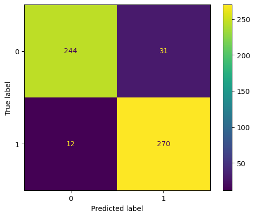

```python
params = {'max_leaf_nodes': list(range(2, 100)), 'max_depth': list(range(5, 10)),'criterion':['entropy','gini']}
dtree = GridSearchCV(tree.DecisionTreeClassifier(random_state=42), params, verbose=1, cv=3)
dtree.fit(x_train,y_train)
predictions = dtree.predict(x_test)
cm = confusion_matrix(y_test, predictions, labels=dtree.classes_)
disp = ConfusionMatrixDisplay(confusion_matrix=cm,display_labels=dtree.classes_)
disp.plot()
plt.show()
```

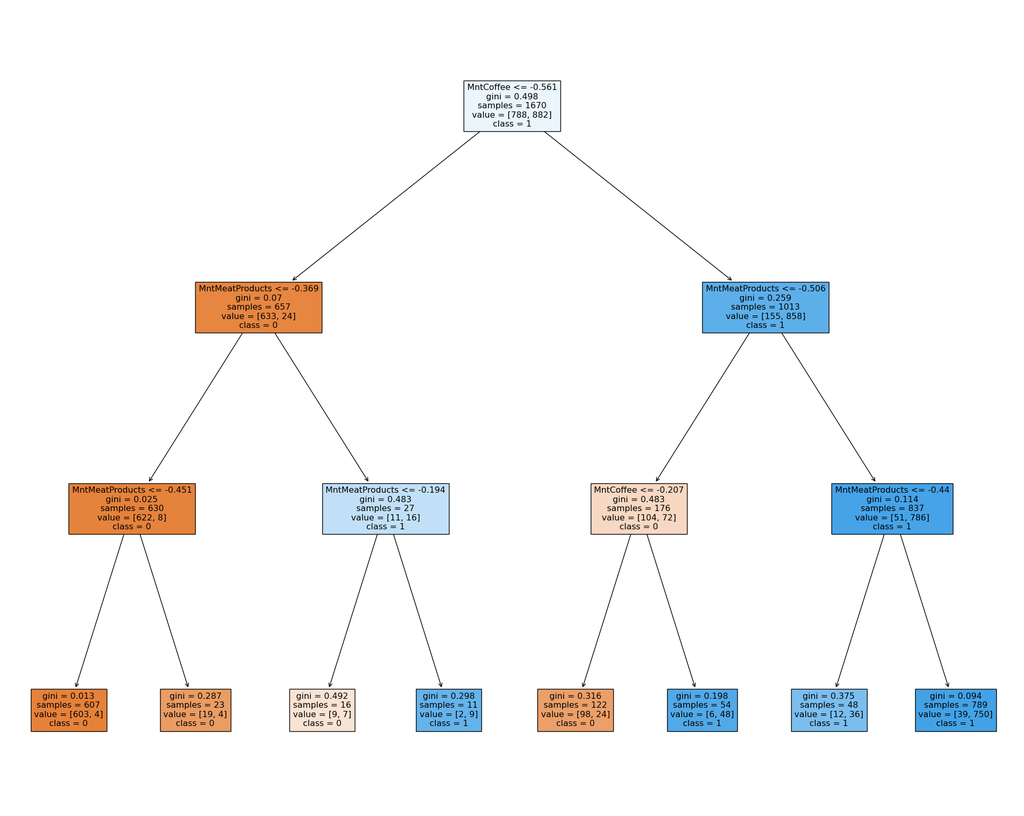

```python
dtree = tree.DecisionTreeClassifier(max_depth=3)
dtree.fit(x_train,y_train)
predictions = dtree.predict(x_test)

fig = plt.figure(figsize=(25,20))
_ = tree.plot_tree(dtree,
                   feature_names=feature_names,
                   class_names=['0','1'],
                   filled=True)
```

```python
predictions = dtree.predict(x_test)
print(f"test f1 score: {f1_score(y_test,predictions)}")
predictions = dtree.predict(x_train)
print(f"train f1 score: {f1_score(y_train,predictions)}")
```

```
test f1 score: 0.9284467713787086
train f1 score: 0.945067264573991
```

Our model does not have overitting problem.

### KNN

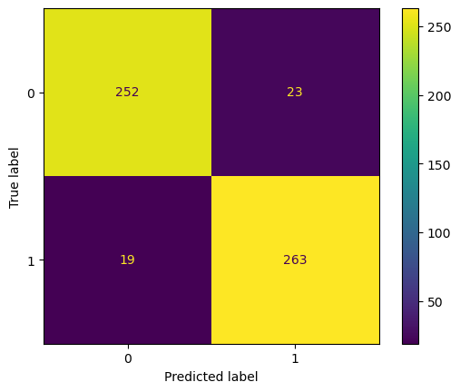

```python
params = {'n_neighbors':[i for i in range(3,14,2)]}
knn = GridSearchCV(neighbors.KNeighborsClassifier(),param_grid=params)
knn.fit(x_train,np.squeeze(y_train))
predictions = knn.predict(x_test)
cm = confusion_matrix(np.squeeze(y_test), predictions, labels=knn.classes_)
disp = ConfusionMatrixDisplay(confusion_matrix=cm,display_labels=knn.classes_)
disp.plot()
plt.show()
```

```python
predictions = knn.predict(x_test)
print(f"test f1 score: {f1_score(y_test,predictions)}")
predictions = knn.predict(x_train)
print(f"train f1 score: {f1_score(y_train,predictions)}")
```

```
test f1 score: 0.9260563380281689
train f1 score: 0.9435665914221218
```

We dont have neither overfitting nor underfitting.

### Logestic Regression

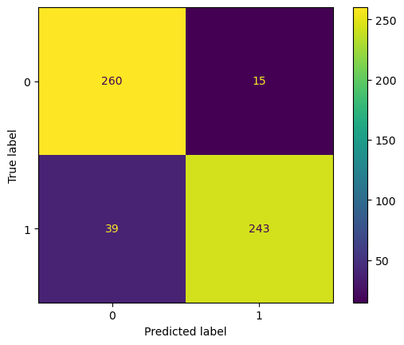

```python
params = {'tol':[0.0001,0.00001,0.000001]}
log = GridSearchCV(linear_model.LogisticRegression(),param_grid=params)
# x_train,x_test,y_train,y_test = train_test_split(np.array(features),purchase_rate.reshape(-1,1))
log.fit(x_train,np.squeeze(y_train))
predictions = log.predict(x_test)
cm = confusion_matrix(np.squeeze(y_test), predictions, labels=log.classes_)
disp = ConfusionMatrixDisplay(confusion_matrix=cm,display_labels=log.classes_)
disp.plot()
plt.show()
```

```python
predictions = log.predict(x_test)
print(f"test f1 score: {f1_score(y_test,predictions)}")
predictions = log.predict(x_train)
print(f"train f1 score: {f1_score(y_train,predictions)}")
```

```
test f1 score: 0.8999999999999999
train f1 score: 0.9149560117302052
```

The model performs well without any overfitting

22. Yes. Scaling features increased performance of the model. But the most affective preprocessing I did was removing outliers which helped our model alot.

## Ensemble Learning

24. Split metric and number of trees are 2 hyperparamethers used in random forests.

```
[]
```

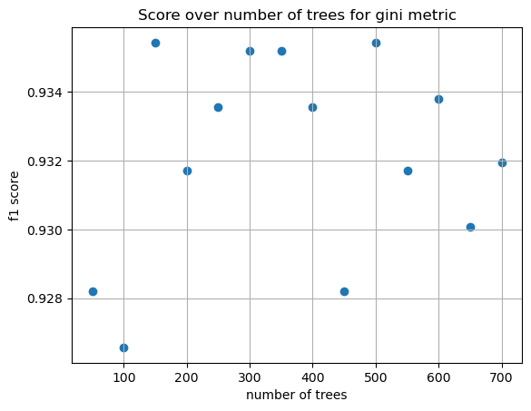

```python
scores =[]
num_of_trees = []
for i in range(1,15):
    rf = ensemble.RandomForestClassifier(n_estimators=50*i,criterion='gini')
    rf.fit(x_train,np.squeeze(y_train))
    preds = rf.predict(x_test)
    scores.append(f1_score(np.squeeze(y_test),preds))
    num_of_trees.append(i*50)


plt.scatter(num_of_trees,scores)
plt.ylabel("f1 score")
plt.xlabel("number of trees")
plt.title('Score over number of trees for gini metric')
plt.grid()
plt.plot()
```

```
test f1 score: 0.9319371727748691
train f1 score: 1.0
```

```
[]
```

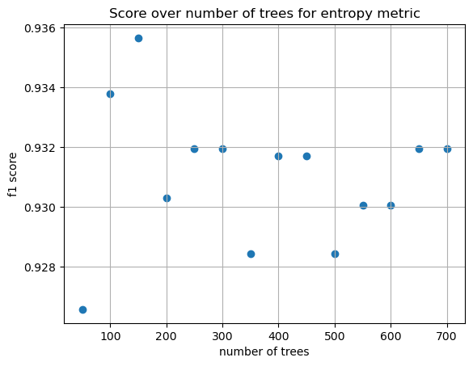

```python
scores =[]
num_of_trees = []
for i in range(1,15):
    rf = ensemble.RandomForestClassifier(n_estimators=50*i,criterion='entropy')
    rf.fit(x_train,np.squeeze(y_train))
    preds = rf.predict(x_test)
    scores.append(f1_score(np.squeeze(y_test),preds))
    num_of_trees.append(i*50)

predictions = rf.predict(x_test)
print(f"test f1 score: {f1_score(y_test,predictions)}")
predictions = rf.predict(x_train)
print(f"train f1 score: {f1_score(y_train,predictions)}")

plt.scatter(num_of_trees,scores)
plt.ylabel("f1 score")
plt.xlabel("number of trees")
plt.title('Score over number of trees for entropy metric')
plt.grid()
plt.plot()
```

[figure not shown]

## Differential Privacy

26. Privacy is an important part of people life and datasets contain a lot of information that can be missused. To prevent information leak we add some noise to our dataset.

27. Laplace adds noise by sampling from Laplace distribution and adding it to each data. Eexponential, however adds noise by sampling from exponential distribution. Laplace noise is better when we want to keep total properties of the dataset

```python
feature_names = ['Income','MntCoffee','MntMeatProducts','Recency','Complain']
for feat in feature_names:
    noise = np.random.laplace(scale=0.1,size= (2227,1))
    df[feat] += np.squeeze(noise)

feature_names = ['Income','MntCoffee','Married','Single','MntMeatProducts','Recency','Complain']
x_train,x_test,y_train,y_test = train_test_split(np.array(df[feature_names]),purchase_rate.reshape(-1,1))
```

```
Fitting 3 folds for each of 980 candidates, totalling 2940 fits
```

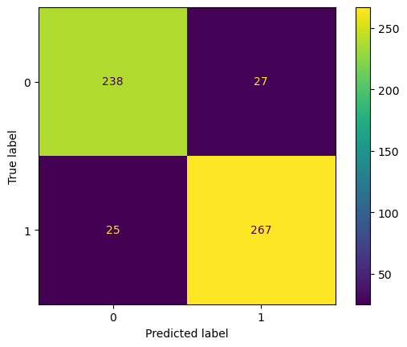

```python
params = {'max_leaf_nodes': list(range(2, 100)), 'max_depth': list(range(5, 10)),'criterion':['entropy','gini']}
dtree = GridSearchCV(tree.DecisionTreeClassifier(random_state=42), params, verbose=1, cv=3)
dtree.fit(x_train,y_train)
predictions = dtree.predict(x_test)
cm = confusion_matrix(y_test, predictions, labels=dtree.classes_)
disp = ConfusionMatrixDisplay(confusion_matrix=cm,display_labels=dtree.classes_)
disp.plot()
plt.show()
```

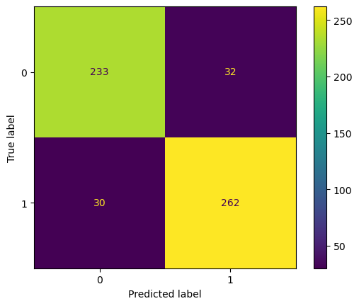

```python
params = {'n_neighbors':[i for i in range(3,14,2)]}
knn = GridSearchCV(neighbors.KNeighborsClassifier(),param_grid=params)
knn.fit(x_train,np.squeeze(y_train))
predictions = knn.predict(x_test)
cm = confusion_matrix(np.squeeze(y_test), predictions, labels=knn.classes_)
disp = ConfusionMatrixDisplay(confusion_matrix=cm,display_labels=knn.classes_)
disp.plot()
plt.show()
```

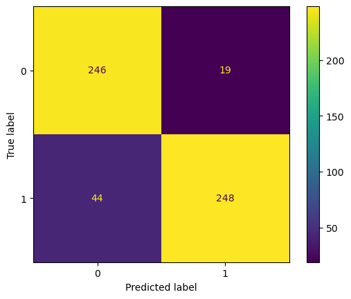

```python
params = {'tol':[0.0001,0.00001,0.000001]}
log = GridSearchCV(linear_model.LogisticRegression(),param_grid=params)
log.fit(x_train,np.squeeze(y_train))
predictions = log.predict(x_test)
cm = confusion_matrix(np.squeeze(y_test), predictions, labels=log.classes_)
disp = ConfusionMatrixDisplay(confusion_matrix=cm,display_labels=log.classes_)
disp.plot()
plt.show()
```

It has decreased performance of our model a bit but that is not really noticable. So it can be a viable method to increase provacy.

## Gradient Boosting

29. in Random forests aggregation of data is done by combining the results at the end. But boosting trees do this aggregation sequentially.

30.Xgboost has a set of decision trees, each of them working on one subset of data. Each classifier output its results to the next tree. This results in high performance of the model

```
f1 score: 0.9191919191919192
```

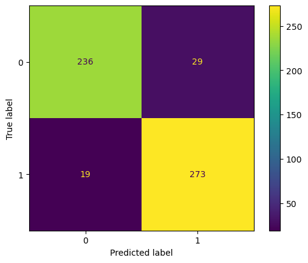

```python
from xgboost import XGBClassifier
model = XGBClassifier()
model.fit(x_train,y_train)
preds = model.predict(x_test)
cm = confusion_matrix(y_test, preds, labels=knn.classes_)
print(f"f1 score: {f1_score(y_test,preds)}")
disp = ConfusionMatrixDisplay(confusion_matrix=cm,display_labels=knn.classes_)
disp.plot()
plt.show()
```